# Prettify Graphs

TUD

Sarah Listabarth, Ronja Huhn

# Why pretty data visualizations

- are more engaging
- help to tell your story

# What makes a good plot

- clear and concise
- informative
- aesthetically pleasing

**Note**

The answer depends on the data and the audience.

**Best way to go:** start with a basic plot and then add layers to it.

# Adding layers to your plot

- Theme
- Legend appearance
- Scales
- Annotations

# Task (3 min)

Install the needed packages and load our data

- Run in console: install.packages(“gapminder”), install.packages(“scales”), install.packages(“ggrepel”) , install.packages(“RColorBrewer”)
- Load the packages
- Have a first look at our data

```r
data(gapminder)
gapminder |> head()
```

# Themes

- Best only include what you really need.
- With themes you can exclude grid lines, axis labels, etc.

## Task (5 min)

Use the cheat sheet in 02- Visualizations and try out different themes. Choose the one you like the most.

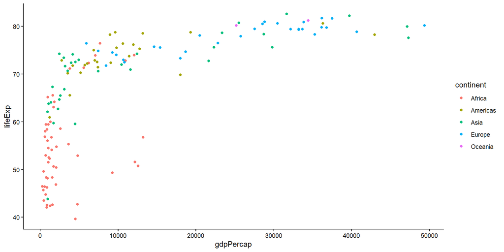

```r
gapminder_plot <-
  gapminder |>
  filter(year == 2007) |>
  ggplot() +
  geom_point(aes(x = gdpPercap, y = lifeExp, color = continent))

gapminder_plot +
  theme_classic()
```

## Task (10 min)

Use `?theme` to find out how to:

- Change the text size
- Change the background colour
- Change the legend position

```r
gapminder_plot +
  theme()
```

## Possible solution

```r
gapminder_plot +
  theme(text = element_text(size = 14), panel.background = element_rect(fill="blue"), legend.position = "bottom")
```

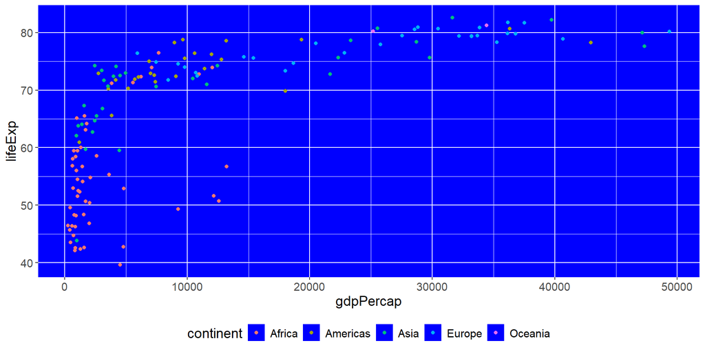

# Scales and Colours

## Which colours to use?

- **Fit:** use colours that fit the data and the message you want to convey.
- **Accessibility:** use colours that are distinguishable for people with colour vision deficiencies.
- **Colour harmony:** use colours that are aesthetically pleasing together.

## Different scales

- **Sequential:** one hue, light to dark → continuous data
- **Qualitative:** different hues → categorical data
- **Diverging:** two hues, light to dark → continuous data with a midpoint

**Useful link:** [ggplot](https://ggplot2-book.org/scales-guides.html)

**Useful packages:** `viridis`, `RColorBrewer`

## Choosing a colour scale

You can choose from the given scales:

- `scale_colour_continuous()` / `scale_colour_discrete()`
- `scale_colour_brewer()`
- `scale_colour_viridis_d()`
- …

Or you can set the colour values manually:

- `scale_colour_manual()`

The gapminder package comes with its own colours: continent_colors

## Task (5 min)

Play around with the different colour palettes, be careful to check which type of scale you need to use

```r
gapminder_plot
```

## Possible solution

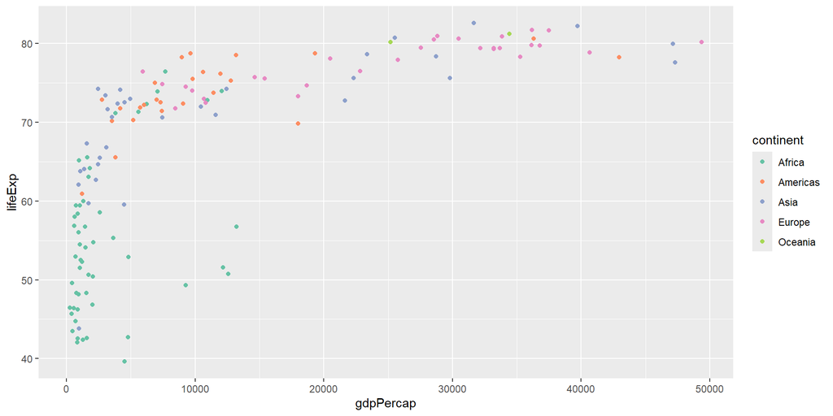

```r
gapminder_plot +
  scale_colour_brewer(type = "qual", palette = "Set2")
```

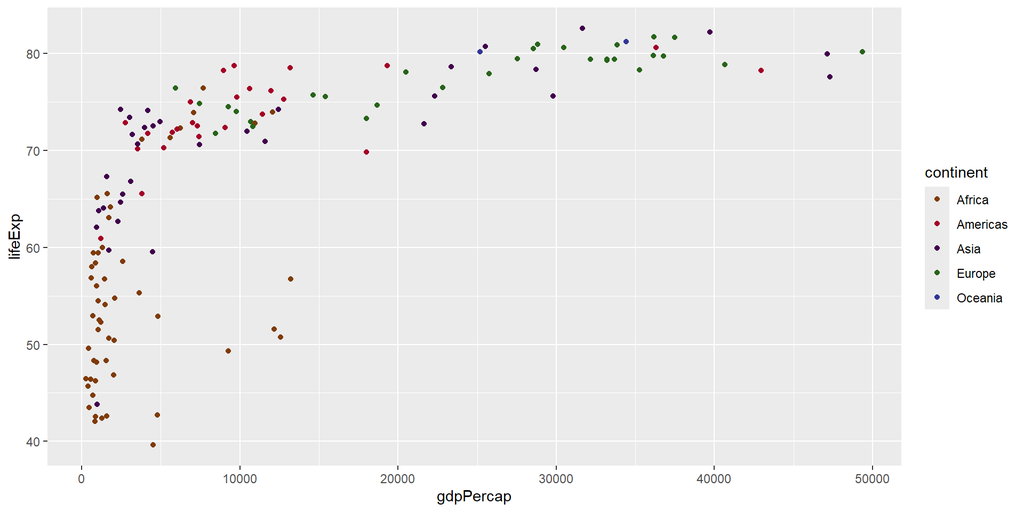

```r
data(continent_colors)

gapminder_plot +
  scale_colour_manual(values = continent_colors)
```

## Changing other scales

Not only colours but also a suitable number format can improve readability

?scale_x_continuous, scale_x_discrete

## Task (10 min)

- Limit the x-Axis to 40,0000
- Change the scale to a label_comma

```r
gapminder_plot
```

## Possible solution

```r
gapminder_plot +
  scale_x_continuous(limits = c(0,40000), labels = scales::label_comma())
```

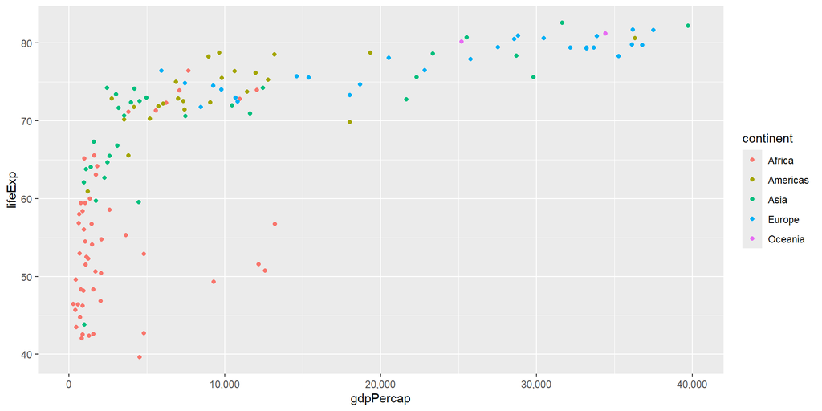

# Annotations

Basic annotations:

- Titles: Describe the content of the plot
- Labels: Describe the axes
- Captions: Describe the plot, e.g. the data source

Additional annotations:

- Text and Highlighting: Describing data points/areas directly

We can use the ggrepel package to add labels, and specifically the function geom_label_repel.

```r
labelled_countries <- gapminder |>
  filter(year == 2007) |>
  filter(lifeExp == max(lifeExp) | lifeExp == min(lifeExp))
```

```r
gapminder_plot +
  geom_label_repel(data = labelled_countries,
aes(
label = country,
x = gdpPercap,
y = lifeExp,
col = continent
),
show.legend = FALSE)
```

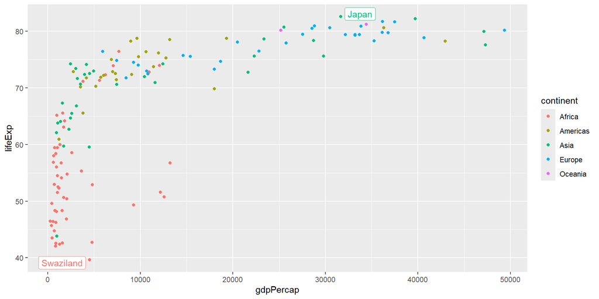

## Task (5min)

Instead of min and max, highlight the country with the highest lifeExp in each continent in 2007

```r
#labelled_countries_per_continent
```

```r
gapminder_plot
```

## Possible solution

```r
labelled_countries_per_continent <- gapminder |>
  filter(year == 2007)|>
  group_by(continent)|>
  filter(lifeExp == max(lifeExp))|>
  ungroup()

gapminder_plot +
  geom_label_repel(data = labelled_countries_per_continent,
aes(
label = country,
x = gdpPercap,
y = lifeExp,
col = continent
),
show.legend = FALSE)
```

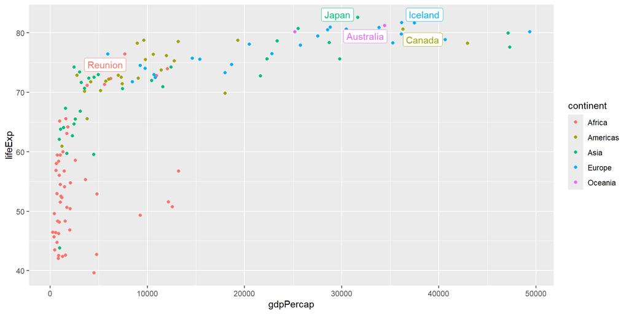